# Non-Stationary Processes in Time Series Analysis

Tan Zheng Liang

2022-08-15

## 1 Introduction

The purpose of this project was to understand non-stationary processes in time series analysis and the difference between deterministic and stochastic trend in time series variables. It also sought to find out if the treatment for achieving stationarity (differencing, de-trending, including trend in regression) affects the accuracy of out-of-sample forecast for time series with a deterministic trend.

The project used a simulation of random walk and ARIMA models and added a drift and/or trend term to simulate non-stationary time series data.

## 2 Packages Required

```r
library(forecast) # For ARIMA modelling, forecasting and evaluation
library(urca) # For unit root and stationarity tests
```

## 3 Non-Stationary Processes

In this section, the different non-stationary processes are introduced, along with the simulation of the processes.

### 3.1 Random Walk

I began the analysis of non-stationary processes with the random walk (RW) model as this model will lay the foundation for the models discussed later.

The RW model has the form $y_t = y_{t-1} + \varepsilon_t$, where $\varepsilon_t \sim N(0, \sigma^2)$. This means that the current value is based on its previous value and a stochastic white noise component.

The model can be easily rewritten with the form $y_t = y_0 + \sum_{s=1}^t \varepsilon_s$ with $E(y_t) = y_0$ and $V(y_t) = t \sigma^2$. The mean is dependent on $y_0$ and without loss of generality, $y_0 = 0$ means that $y_t$ is random and cannot be accurately predicted. The variance is dependent on and increases with time.

Using **`stats::arima.sim()`**, we can simulate the RW model as such:

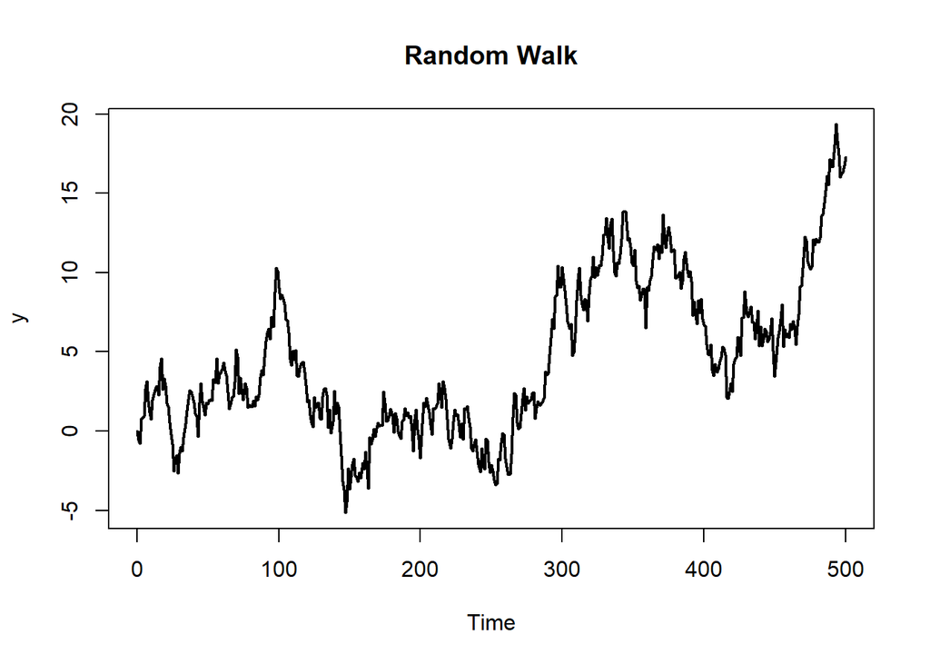

```r
# Number of observations
N = 500

# Model to simulate
# For RW model, only need d = 1 in (p,d,q) to include unit root
M = list(order = c(0, 1, 0))

set.seed(123)

RW <- stats::arima.sim(model = M, n = N)

# Plot RW
plot(x = RW, main = "Random Walk", ylab = "y", lwd = 2)
```

Using **`urca::ur.df()`** and **`urca::ur.kpss`**, the Augmented Dickey Fuller test for unit root and KPSS test for stationarity can be performed:

```r
RW %>% urca::ur.df(type = "none", selectlags = "AIC") %>% summary()
```

```
##
## ###############################################
## # Augmented Dickey-Fuller Test Unit Root Test #
## ###############################################
##
## Test regression none
##
##
## Call:
## lm(formula = z.diff ~ z.lag.1 - 1 + z.diff.lag)
##
## Residuals:
##     Min      1Q  Median      3Q     Max
## -2.6493 -0.5908  0.0341  0.6822  3.1660
##
## Coefficients:
##             Estimate Std. Error t value Pr(>|t|)
## z.lag.1    -0.003077   0.006604  -0.466    0.642
## z.diff.lag -0.050654   0.045091  -1.123    0.262
##
## Residual standard error: 0.9734 on 497 degrees of freedom
## Multiple R-squared:  0.003255,   Adjusted R-squared:  -0.0007556
## F-statistic: 0.8116 on 2 and 497 DF,  p-value: 0.4447
##
##
## Value of test-statistic is: -0.4659
##
## Critical values for test statistics:
##       1pct  5pct 10pct
## tau1 -2.58 -1.95 -1.62
```

```r
# KPSS requires a deterministic component, either drift (mu) or trend (tau)
RW %>% urca::ur.kpss(type = "mu", lags = "short") %>% summary()
```

```
##
## #######################
## # KPSS Unit Root Test #
## #######################
##
## Test is of type: mu with 5 lags.
##
## Value of test-statistic is: 4.0069
##
## Critical value for a significance level of:
##                 10pct  5pct 2.5pct  1pct
## critical values 0.347 0.463  0.574 0.739
```

The null hypothesis of the ADF test cannot be rejected (there is unit root) and the null hypothesis of the KPSS test was rejected (not stationary).

### 3.2 Random Walk with Drift

The second non-stationary process is a random walk model with drift (or constant). When plotted, the RW model with drift would look like a trending series. A positive/negative constant would produce a upward/downward trending RW series.

This model can be represented by $y_t = \alpha + y_{t-1} + \varepsilon_t$, where $\varepsilon_t \sim N(0, \sigma^2)$. This is similar to the RW model, with the current value also affected by a drift (or constant) term.

It is easily shown that the model can be rewritten as $y_t = t \alpha + y_0 + \sum_{s = 1}^t \varepsilon_s$, with $E(y_t) = t \alpha + y_0$ and $V(y_t) = t \sigma^2$. WLOG, $y_0 = 0$ shows that the mean is increasing with time. Same as the RW model, the variance of the RW model with drift is time-dependent and increases with time.

Using **`stats::arima.sim()`**, we can simulate the RW model with drift as such:

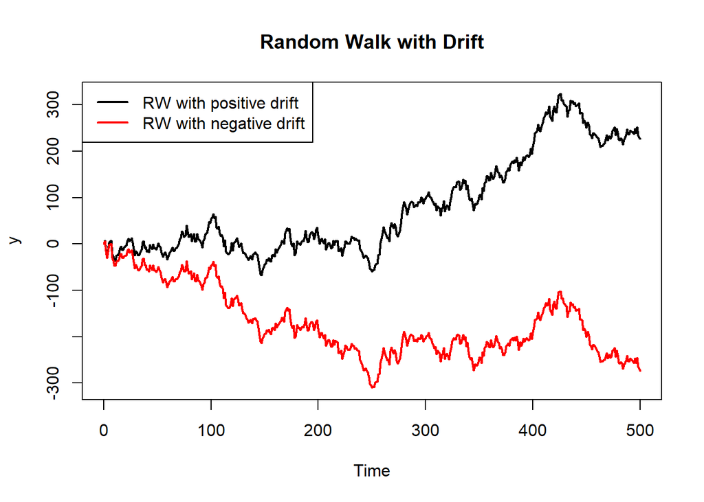

```r
# Use same number of observations (N) and model (M) as RW model

# Include a non-zero mean value and optionally the standard deviation
# RW with positive constant
set.seed(234)
RW_posDrift <- stats::arima.sim(model = M, n = N, mean = 0.5, sd = 10)

# RW with negative constant
set.seed(234)
RW_negDrift <- stats::arima.sim(model = M, n = N, mean = -0.5, sd = 10)

# Plot RW with drift
plot(x = cbind(RW_posDrift, RW_negDrift),
     main = "Random Walk with Drift", ylab = "y",
     plot.type = "single",
     col = c("black", "red"), lwd = 2)

legend(x = "topleft", legend = c("RW with positive drift", "RW with negative drift"),
       col = c("black", "red"), lwd = 2)
```

Perform ADF and KPSS tests for the RW model with positive constant:

```r
RW_posDrift %>% urca::ur.df(type = "drift", selectlags = "AIC") %>% summary()
```

```
##
## ###############################################
## # Augmented Dickey-Fuller Test Unit Root Test #
## ###############################################
##
## Test regression drift
##
##
## Call:
## lm(formula = z.diff ~ z.lag.1 + 1 + z.diff.lag)
##
## Residuals:
##      Min       1Q   Median       3Q      Max
## -30.3934  -6.1937   0.6209   6.4644  28.8047
##
## Coefficients:
##              Estimate Std. Error t value Pr(>|t|)
## (Intercept)  0.657396   0.543495   1.210    0.227
## z.lag.1     -0.002492   0.004093  -0.609    0.543
## z.diff.lag  -0.041102   0.044913  -0.915    0.361
##
## Residual standard error: 9.716 on 496 degrees of freedom
## Multiple R-squared:  0.002576,   Adjusted R-squared:  -0.001445
## F-statistic: 0.6406 on 2 and 496 DF,  p-value: 0.5274
##
##
## Value of test-statistic is: -0.6088 0.7418
##
## Critical values for test statistics:
##       1pct  5pct 10pct
## tau2 -3.43 -2.86 -2.57
## phi1  6.43  4.59  3.78
```

```r
RW_posDrift %>% urca::ur.kpss(type = "mu", lags = "short") %>% summary()
```

```
##
## #######################
## # KPSS Unit Root Test #
## #######################
##
## Test is of type: mu with 5 lags.
##
## Value of test-statistic is: 6.9035
##
## Critical value for a significance level of:
##                 10pct  5pct 2.5pct  1pct
## critical values 0.347 0.463  0.574 0.739
```

The null hypothesis of the ADF test cannot be rejected (there is unit root) and the null hypothesis of the KPSS test was rejected (not stationary).